# Reproducible Research: Peer Assessment 1

```r
#install.packages("mice")
library(dplyr)
```

```r
library(ggplot2)
require(plyr)
require(Hmisc)
dat <- read.table("activity.csv",header=T,sep=",")

head(dat)
```

```
##   steps       date interval
## 1    NA 2012-10-01        0
## 2    NA 2012-10-01        5
## 3    NA 2012-10-01       10
## 4    NA 2012-10-01       15
## 5    NA 2012-10-01       20
## 6    NA 2012-10-01       25
```

```r
typeof(dat)
```

```
## [1] "list"
```

### create a new variable - dataFrame

```r
dt <- data.frame(dat)
head(dt)
```

```
##   steps       date interval
## 1    NA 2012-10-01        0
## 2    NA 2012-10-01        5
## 3    NA 2012-10-01       10
## 4    NA 2012-10-01       15
## 5    NA 2012-10-01       20
## 6    NA 2012-10-01       25
```

## What is mean total number of steps taken per day?

### 1. Calculate the total number of steps taken per day

```r
steps_per_day <- aggregate(steps ~ date, data=dt, FUN=sum)
```

```r
head(steps_per_day)
```

```
##         date steps
## 1 2012-10-02   126
## 2 2012-10-03 11352
## 3 2012-10-04 12116
## 4 2012-10-05 13294
## 5 2012-10-06 15420
## 6 2012-10-07 11015
```

## Make a histogram of the total number of steps taken each day

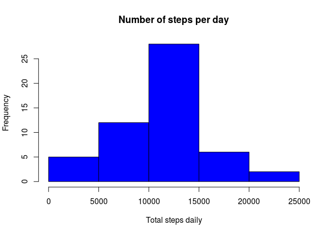

```r
hist(steps_per_day$steps, col="blue",xlab = "Total steps daily",
        main = "Number of steps per day")
```

### Calculate the mean and median of the total number of steps taken per day

```r
median(steps_per_day$steps,na.rm = TRUE)
```

```
## [1] 10765
```

```r
mean(steps_per_day$steps,na.rm = TRUE)
```

```
## [1] 10766.19
```

## What is the average daily activity pattern?

### 1. Make a time series plot (i.e. type = “l”) of the 5-minute interval (x-axis) and the average number of steps taken, averaged across all days (y-axis)

```r
steps_i <- aggregate(steps ~ interval, data = dt, FUN = mean, na.rm = TRUE)
str(steps_i)
```

```
## 'data.frame':    288 obs. of  2 variables:
##  $ interval: int  0 5 10 15 20 25 30 35 40 45 ...
##  $ steps   : num  1.717 0.3396 0.1321 0.1509 0.0755 ...
```

## timeseries graph

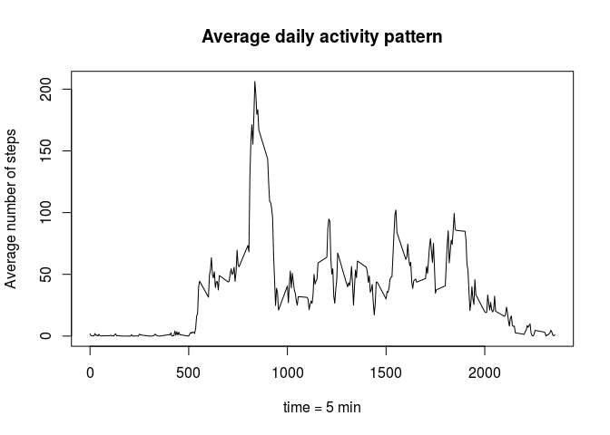

```r
plot(steps_i$interval,steps_i$steps,type="l",xlab="time = 5 min",
        ylab="Average number of steps",main="Average daily activity pattern")
```

## 2. Which 5-minute interval, on average across all the days in the dataset, contains the maximum number of steps?

```r
max_i <- steps_i[which.max(steps_i$steps),]
max_i
```

```
##     interval    steps
## 104      835 206.1698
```

## Imputing missing values

### 1. Calculate and report the total number of missing values in the dataset (i.e. the total number of rows with NAs)

```r
cout_missing_values <- sum(is.na(dt$steps))
cout_missing_values
```

```
## [1] 2304
```

### 2. Fill in all of the missing values in the dataset

### 3. Create a new dataset that is equal to the original dataset but with the missing data filled in.

```r
dt_Imputed <- ddply(dt, "interval", mutate, imputed.value = impute(steps, mean))
#dt_Imputed <- ddply(dt$steps, mean)
```

```r
median(dt_Imputed$steps,na.rm = TRUE)
```

```
## [1] 0
```

```r
mean(dt_Imputed$steps,na.rm = TRUE)
```

```
## [1] 37.3826
```

## alternative way

```r
fillITin <-  function(x){

x$steps[is.na(x$steps)] <- ave(x$steps,
                                     FUN = function(z)
                                    mean(z, na.rm = TRUE))[c(which(is.na(x$steps)))]
return(x)
}


dt_Inputed_2 <- fillITin(dt)
```

```r
median(dt_Inputed_2$steps,na.rm = TRUE)
```

```
## [1] 0
```

```r
mean(dt_Inputed_2$steps,na.rm = TRUE)
```

```
## [1] 37.3826
```

[figure not shown]

```r
hist(dt_Inputed_2$steps, col="light blue",xlab = "Total steps daily",
         main = "Number of steps per day with imputed values")
```

```r
mean(dt_Inputed_2$steps,na.rm = TRUE)
```

```
## [1] 37.3826
```

```r
median(dt_Inputed_2$steps,na.rm = TRUE)
```

```
## [1] 0
```

## Are there differences in activity patterns between weekdays and weekends?

### 1. Create a new factor variable in the dataset with two levels - “weekday” and “weekend” indicating whether a given date is a weekday or weekend day.

```r
dt_Inputed_2$dateType <-  ifelse(as.POSIXlt(dt_Inputed_2$date)$wday %in% c(0,6), 'weekend', 'weekday')
```

### 2. Make a panel plot containing a time series plot (i.e. type = “l”) of the 5-minute interval (x-axis) and the average number of steps taken, averaged across all weekday days or weekend days (y-axis)

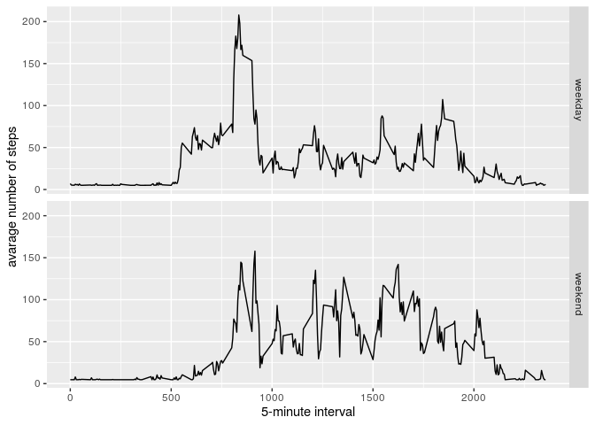

```r
av_dt_Inputed_2 <- aggregate(steps ~ interval + dateType, data=dt_Inputed_2, mean)
ggplot(av_dt_Inputed_2, aes(interval, steps)) +
    geom_line() +
    facet_grid(dateType ~ .) +
    xlab("5-minute interval") +
    ylab("avarage number of steps")
```